# Read data from our directory

```r
data = read.csv(file.choose(),header = TRUE)
head(data)
```

```
##   Pregnancies Glucose BloodPressure SkinThickness Insulin  BMI
## 1           6     148            72            35       0 33.6
## 2           1      85            66            29       0 26.6
## 3           8     183            64             0       0 23.3
## 4           1      89            66            23      94 28.1
## 5           0     137            40            35     168 43.1
## 6           5     116            74             0       0 25.6
##   DiabetesPedigreeFunction Age Outcome
## 1                    0.627  50       1
## 2                    0.351  31       0
## 3                    0.672  32       1
## 4                    0.167  21       0
## 5                    2.288  33       1
## 6                    0.201  30       0
```

# find the summary of the data

```r
summary(data)
```

```
##   Pregnancies        Glucose      BloodPressure    SkinThickness
##  Min.   : 0.000   Min.   :  0.0   Min.   :  0.00   Min.   : 0.00
##  1st Qu.: 1.000   1st Qu.: 99.0   1st Qu.: 62.00   1st Qu.: 0.00
##  Median : 3.000   Median :117.0   Median : 72.00   Median :23.00
##  Mean   : 3.845   Mean   :120.9   Mean   : 69.11   Mean   :20.54
##  3rd Qu.: 6.000   3rd Qu.:140.2   3rd Qu.: 80.00   3rd Qu.:32.00
##  Max.   :17.000   Max.   :199.0   Max.   :122.00   Max.   :99.00
##     Insulin           BMI        DiabetesPedigreeFunction      Age
##  Min.   :  0.0   Min.   : 0.00   Min.   :0.0780           Min.   :21.00
##  1st Qu.:  0.0   1st Qu.:27.30   1st Qu.:0.2437           1st Qu.:24.00
##  Median : 30.5   Median :32.00   Median :0.3725           Median :29.00
##  Mean   : 79.8   Mean   :31.99   Mean   :0.4719           Mean   :33.24
##  3rd Qu.:127.2   3rd Qu.:36.60   3rd Qu.:0.6262           3rd Qu.:41.00
##  Max.   :846.0   Max.   :67.10   Max.   :2.4200           Max.   :81.00
##     Outcome
##  Min.   :0.000
##  1st Qu.:0.000
##  Median :0.000
##  Mean   :0.349
##  3rd Qu.:1.000
##  Max.   :1.000
```

# find the structure of the data

```r
str(data)
```

```
## 'data.frame':    768 obs. of  9 variables:
##  $ Pregnancies             : int  6 1 8 1 0 5 3 10 2 8 ...
##  $ Glucose                 : int  148 85 183 89 137 116 78 115 197 125 ...
##  $ BloodPressure           : int  72 66 64 66 40 74 50 0 70 96 ...
##  $ SkinThickness           : int  35 29 0 23 35 0 32 0 45 0 ...
##  $ Insulin                 : int  0 0 0 94 168 0 88 0 543 0 ...
##  $ BMI                     : num  33.6 26.6 23.3 28.1 43.1 25.6 31 35.3 30.5 0 ...
##  $ DiabetesPedigreeFunction: num  0.627 0.351 0.672 0.167 2.288 ...
##  $ Age                     : int  50 31 32 21 33 30 26 29 53 54 ...
##  $ Outcome                 : int  1 0 1 0 1 0 1 0 1 1 ...
```

```r
data$Outcome=as.factor(data$Outcome)
str(data)
```

```
## 'data.frame':    768 obs. of  9 variables:
##  $ Pregnancies             : int  6 1 8 1 0 5 3 10 2 8 ...
##  $ Glucose                 : int  148 85 183 89 137 116 78 115 197 125 ...
##  $ BloodPressure           : int  72 66 64 66 40 74 50 0 70 96 ...
##  $ SkinThickness           : int  35 29 0 23 35 0 32 0 45 0 ...
##  $ Insulin                 : int  0 0 0 94 168 0 88 0 543 0 ...
##  $ BMI                     : num  33.6 26.6 23.3 28.1 43.1 25.6 31 35.3 30.5 0 ...
##  $ DiabetesPedigreeFunction: num  0.627 0.351 0.672 0.167 2.288 ...
##  $ Age                     : int  50 31 32 21 33 30 26 29 53 54 ...
##  $ Outcome                 : Factor w/ 2 levels "0","1": 2 1 2 1 2 1 2 1 2 2 ...
```

# find missing values

```r
sapply(data, function(x) sum(is.na(x)))
```

```
##              Pregnancies                  Glucose            BloodPressure
##                        0                        0                        0
##            SkinThickness                  Insulin                      BMI
##                        0                        0                        0
## DiabetesPedigreeFunction                      Age                  Outcome
##                        0                        0                        0
```

# missing data through graphically

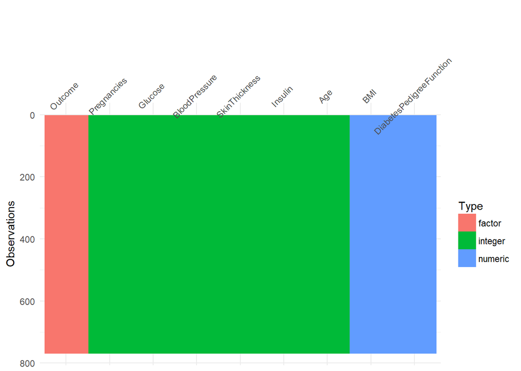

```r
library(visdat)
vis_dat(data)
```

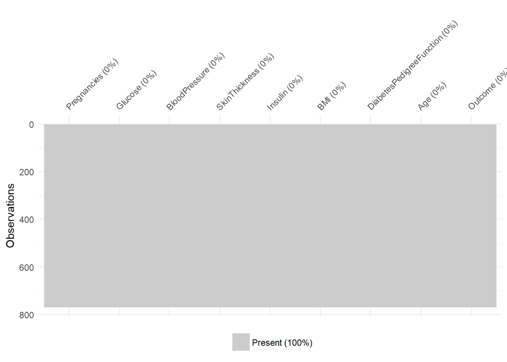

```r
vis_miss(data)
```

vis_dat:- visualises the whole dataframe at once, and provides information about the class of the data input into R, as well as whether the data is missing or not.

vis_miss :- The function vis_miss provides a summary of whether the data is missing or not. It also provides the amount of missings in each columns.

we know that there is no missing data in dataset

now we will se how man people are diabetic

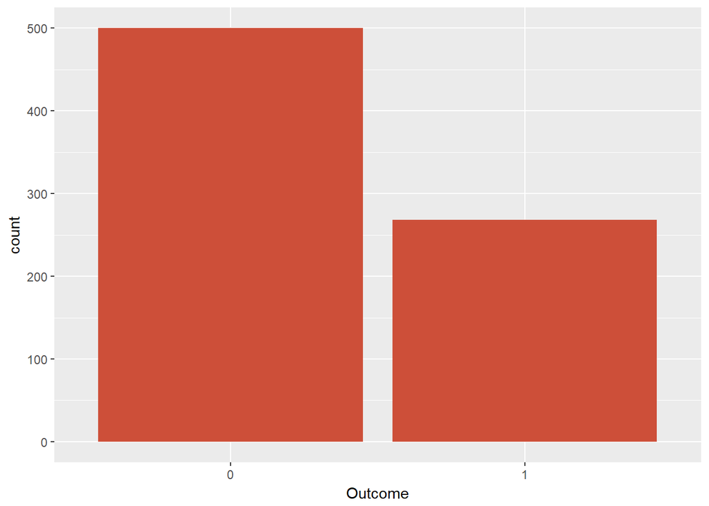

```r
library(ggplot2)
ggplot(data, aes(Outcome)) +geom_bar(fill = "tomato3")
```

```r
table(data$Outcome)
```

```
##
##   0   1
## 500 268
```

0 indicates not Diabetic 1 indicates theyy are diabetic

# How varibles are distributed

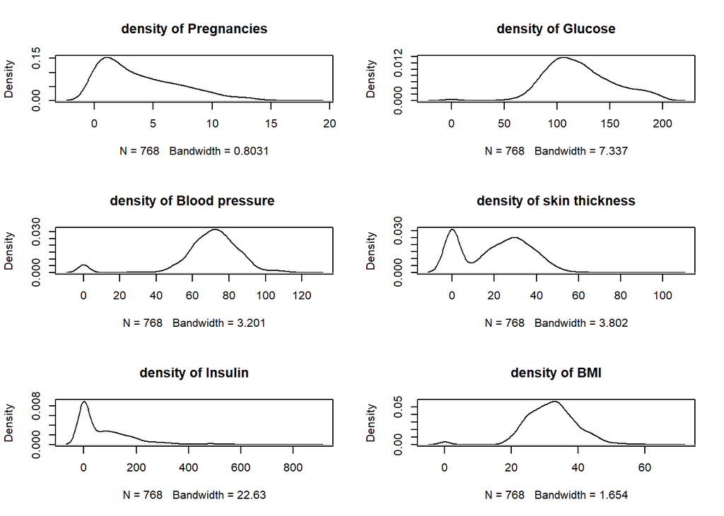

```r
par(mfrow = c(3, 2))
  p = density(data$Pregnancies)
  plot(p , main="density of Pregnancies")

   g = density(data$Glucose)
   plot(g , main="density of Glucose")

   bp= density(data$BloodPressure)
   plot(bp , main="density of Blood pressure ")

   s = density(data$SkinThickness)
   plot(s, main="density of skin thickness")

   i = density(data$Insulin)
   plot(i , main="density of Insulin")

   bm= density(data$BMI)
   plot(bm , main="density of BMI")
```

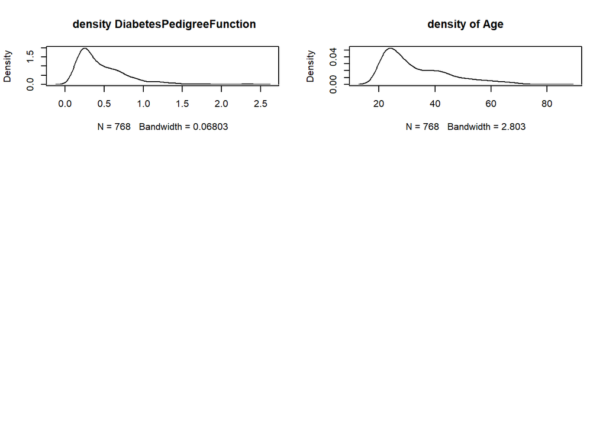

```r
   dp = density(data$DiabetesPedigreeFunction)
   plot(dp , main=" density DiabetesPedigreeFunction")

   a= density(data$Age)
   plot(a , main="density of Age")
```

The graphs show some of the distributions of the variables. Age and number of times pregnant are not normal distributions as expected since the underlying population should not be normally distributed either.

On the other hand, the glucose level and BMI seem to follow a normal distribution. When performing any analysis, it is always good to know what is the distribution of the data so all the assumptions for different tests or models can be met.

# Let’s see the correlation between numerical variables

varibles must be the numeric therefore convert them as numeric

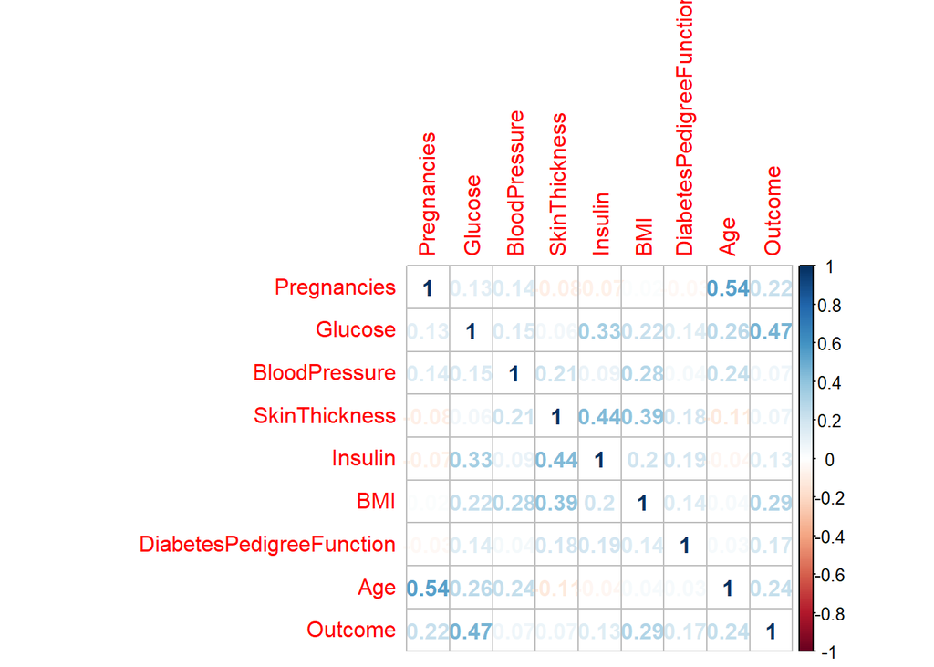

```r
data$Pregnancies=as.numeric(data$Pregnancies)
data$Glucose=as.numeric(data$Glucose)
data$BloodPressure=as.numeric(data$BloodPressure)
data$SkinThickness=as.numeric(data$SkinThickness)
data$Insulin=as.numeric(data$Insulin)
data$Age=as.numeric(data$Age)
data$Outcome=as.numeric(data$Outcome)

library(corrplot)
c <- cor(data)
corrplot(c, method="number")
```

```r
data$Outcome=as.numeric(data$Outcome)
```

more corelated elements should be eliminated and not be considered

divide the dataset into two parts testing and training

```r
library(caTools)
set.seed(123)
s= sample.split(data,SplitRatio = 0.7)
train =subset(data,s==TRUE)
test=subset(data,s==FALSE)
```

# Modeling - Decission Tree

```r
library(rpart)
```

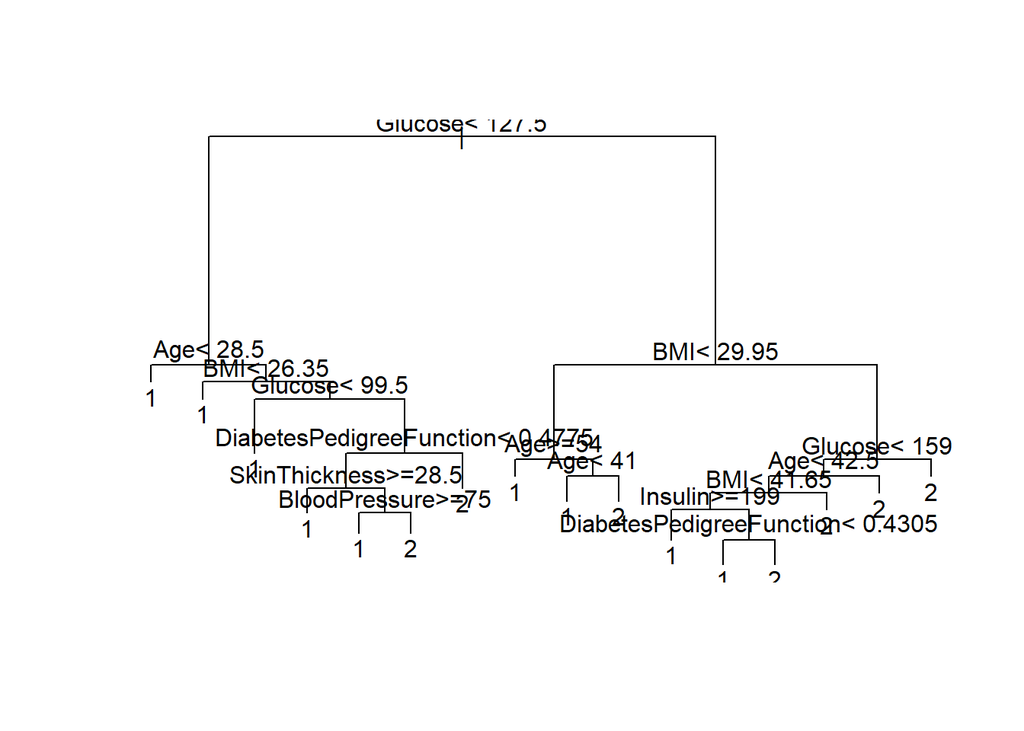

```r
model = rpart(Outcome~.,data = train,method = "class")
#visualise the model
plot(model)
text(model, pretty = 0)
```

# Testing

```r
library(caret)
p <- predict(model, newdata = test[,-9], type = "class" )

confusionMatrix(
  factor(p, levels = 1:2),
  factor(test$Outcome, levels = 1:2)
)
```

```
## Confusion Matrix and Statistics
##
##           Reference
## Prediction   1   2
##          1 134  30
##          2  32  59
##
##                Accuracy : 0.7569
##                  95% CI : (0.6994, 0.8082)
##     No Information Rate : 0.651
##     P-Value [Acc > NIR] : 0.0001751
##
##                   Kappa : 0.4677
##  Mcnemar's Test P-Value : 0.8989403
##
##             Sensitivity : 0.8072
##             Specificity : 0.6629
##          Pos Pred Value : 0.8171
##          Neg Pred Value : 0.6484
##              Prevalence : 0.6510
##          Detection Rate : 0.5255
##    Detection Prevalence : 0.6431
##       Balanced Accuracy : 0.7351
##
##        'Positive' Class : 1
##
```

# our accuracy is 75 %